In [1]:

In [1]: runfile('/Users/sourabh/Desktop/Udacity/DAND/github_upload/Udacity-Data-Analyst-Projects/Project 6 - Machine Learning/final_project/poi_id.py', wdir='/Users/sourabh/Desktop/Udacity/DAND/github_upload/Udacity-Data-Analyst-Projects/Project 6 - Machine Learning/final_project')

-- Total salary & bonus Values Outliers --

LAVORATO JOHN J --- salary <339288>, bonus <8000000>, POI <False>

WHALLEY LAWRENCE G --- salary <510364>, bonus <3000000>, POI <False>

LAY KENNETH L --- salary <1072321>, bonus <7000000>, POI <True>

SKILLING JEFFREY K --- salary <1111258>, bonus <5600000>, POI <True>

FREVERT MARK A --- salary <1060932>, bonus <2000000>, POI <False>

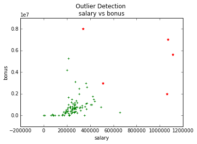

-- Total expenses & other Values Outliers --

LAY KENNETH L --- expenses <99832>, other <10359729>, POI <True>

FREVERT MARK A --- expenses <86987>, other <7427621>, POI <False>

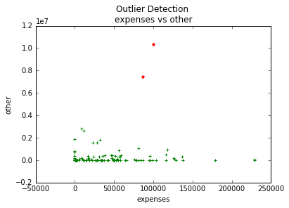

-- Total total_payments & total_stock_value Values Outliers --

BAXTER JOHN C --- total_payments <5634343>, total_stock_value <10623258>, POI <False>

LAY KENNETH L --- total_payments <103559793>, total_stock_value <49110078>, POI <True>

SKILLING JEFFREY K --- total_payments <8682716>, total_stock_value <26093672>, POI <True>

FREVERT MARK A --- total_payments <17252530>, total_stock_value <14622185>, POI <False>

PAI LOU L --- total_payments <3123383>, total_stock_value <23817930>, POI <False>

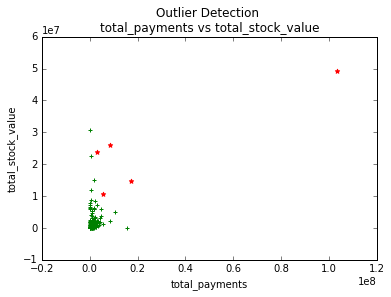

----- Basic Models ----

Classifer --- <Naive Bayes>

Gaussian Naive Bayes Score : 0.733333333333

GaussianNB(priors=None)

Accuracy: 0.71480 Precision: 0.25196 Recall: 0.57850 F1: 0.35103 F2: 0.45942

Total predictions: 15000 True positives: 1157 False positives: 3435 False negatives: 843 True negatives: 9565

------------------------------

Classifer --- <SVM>

Support Vector model Score : 0.933333333333

Got a divide by zero when trying out: SVC(C=1.0, cache_size=200, class_weight=None, coef0=0.0,

decision_function_shape=None, degree=3, gamma='auto', kernel='rbf',

max_iter=-1, probability=False, random_state=None, shrinking=True,

tol=0.001, verbose=False)

Precision or recall may be undefined due to a lack of true positive predicitons.

------------------------------

Classifer --- <Decision Tree>

Decision Tree model Score : 0.866666666667

DecisionTreeClassifier(class_weight=None, criterion='gini', max_depth=None,

max_features=None, max_leaf_nodes=None,

min_impurity_split=1e-07, min_samples_leaf=1,

min_samples_split=2, min_weight_fraction_leaf=0.0,

presort=False, random_state=None, splitter='best')

Accuracy: 0.80487 Precision: 0.26243 Recall: 0.25600 F1: 0.25917 F2: 0.25726

Total predictions: 15000 True positives: 512 False positives: 1439 False negatives: 1488 True negatives: 11561

------------------------------

Classifer --- <KNN>

K Nearest Nerighbor model Score : 1.0

KNeighborsClassifier(algorithm='auto', leaf_size=30, metric='minkowski',

metric_params=None, n_jobs=1, n_neighbors=5, p=2,

weights='uniform')

Accuracy: 0.88400 Precision: 0.73297 Recall: 0.20450 F1: 0.31978 F2: 0.23896

Total predictions: 15000 True positives: 409 False positives: 149 False negatives: 1591 True negatives: 12851

------------------------------

----- Advanced Models ----

Classifer --- <Random Forest>

Random Forest Classifier Score : 0.933333333333

RandomForestClassifier(bootstrap=True, class_weight=None, criterion='gini',

max_depth=None, max_features='auto', max_leaf_nodes=None,

min_impurity_split=1e-07, min_samples_leaf=1,

min_samples_split=2, min_weight_fraction_leaf=0.0,

n_estimators=10, n_jobs=-1, oob_score=False, random_state=42,

verbose=0, warm_start=False)

Accuracy: 0.85900 Precision: 0.42177 Recall: 0.15500 F1: 0.22669 F2: 0.17745

Total predictions: 15000 True positives: 310 False positives: 425 False negatives: 1690 True negatives: 12575

Time taken for the classifier : 323.8 sec

------------------------------

Classifer --- <Extra Trees Classifier>

Extra Tree Classifier Score : 0.868351286956

Feature ranking for ET Classifier:

1. feature stock_to_payment_ratio (0.131569)

2. feature poi (0.081530)

3. feature exercised_stock_options (0.078790)

4. feature salary (0.075859)

5. feature total_stock_value (0.069299)

6. feature director_fees (0.055107)

7. feature cost_to_company (0.048156)

8. feature restricted_stock (0.045974)

9. feature bonus (0.045089)

10. feature total_payments (0.039639)

11. feature other (0.018988)

Got a divide by zero when trying out: ExtraTreesClassifier(bootstrap=False, class_weight=None, criterion='gini',

max_depth=None, max_features=0.1, max_leaf_nodes=None,

min_impurity_split=1e-07, min_samples_leaf=2,

min_samples_split=10, min_weight_fraction_leaf=0.0,

n_estimators=100, n_jobs=1, oob_score=False, random_state=42,

verbose=0, warm_start=False)

Precision or recall may be undefined due to a lack of true positive predicitons.

Time taken for the classifier : 387.25 sec

------------------------------

Classifer --- <Bagging Classifier>

Bagging Score : 1.0

BaggingClassifier(base_estimator=KNeighborsClassifier(algorithm='auto', leaf_size=2, metric='minkowski',

metric_params=None, n_jobs=-1, n_neighbors=1, p=2,

weights='uniform'),

bootstrap=True, bootstrap_features=False, max_features=0.5,

max_samples=0.5, n_estimators=10, n_jobs=1, oob_score=False,

random_state=None, verbose=0, warm_start=False)

Accuracy: 0.86853 Precision: 0.53097 Recall: 0.12000 F1: 0.19576 F2: 0.14198

Total predictions: 15000 True positives: 240 False positives: 212 False negatives: 1760 True negatives: 12788

Time taken for the classifier : 1419.38 sec

------------------------------

Classifer --- <Ada Boost Classifier>

AdaBoostClassifier(algorithm='SAMME.R',

base_estimator=DecisionTreeClassifier(class_weight=None, criterion='gini', max_depth=3,

max_features=None, max_leaf_nodes=None,

min_impurity_split=1e-07, min_samples_leaf=1,

min_samples_split=2, min_weight_fraction_leaf=0.0,

presort=False, random_state=None, splitter='best'),

learning_rate=1.0, n_estimators=70, random_state=None)

Accuracy: 0.83940 Precision: 0.30616 Recall: 0.16150 F1: 0.21146 F2: 0.17835

Total predictions: 15000 True positives: 323 False positives: 732 False negatives: 1677 True negatives: 12268

Time taken for the classifier : 217.71 sec

------------------------------

----- SVC Pipeline Model ----

Best Estimator:

------------------

Pipeline(steps=[('feature_transformer', MinMaxScaler(copy=True, feature_range=(0, 1))), ('selection', SelectKBest(k='all', score_func=<function f_classif at 0x10f22ea28>)), ('reduce_dim', PCA(copy=True, iterated_power='auto', n_components=4, random_state=None,

svd_solver='auto', tol=0.0, whiten=True)), ('c...,

max_iter=-1, probability=False, random_state=None, shrinking=True,

tol=0.001, verbose=False))])

SVC Best Model Score : 0.6

Pipeline(steps=[('feature_transformer', MinMaxScaler(copy=True, feature_range=(0, 1))), ('selection', SelectKBest(k='all', score_func=<function f_classif at 0x10f22ea28>)), ('reduce_dim', PCA(copy=True, iterated_power='auto', n_components=4, random_state=None,

svd_solver='auto', tol=0.0, whiten=True)), ('c...,

max_iter=-1, probability=False, random_state=None, shrinking=True,

tol=0.001, verbose=False))])

Accuracy: 0.78560 Precision: 0.20600 Recall: 0.21300 F1: 0.20944 F2: 0.21156

Total predictions: 15000 True positives: 426 False positives: 1642 False negatives: 1574 True negatives: 11358

Time taken to test the classifier : 10.75 sec

------------------------------

----- LSVC Pipeline Model ----

Best Estimator:

------------------

Pipeline(steps=[('feature_transformer', MinMaxScaler(copy=True, feature_range=(0, 1))), ('selection', SelectKBest(k=7, score_func=<function f_classif at 0x10f22ea28>)), ('reduce_dim', PCA(copy=True, iterated_power='auto', n_components=4, random_state=None,

svd_solver='auto', tol=0.0, whiten=True)), ('clf',...ax_iter=1000,

multi_class='ovr', penalty='l2', random_state=None, tol=0.0001,

verbose=0))])

LSVC Best Model Score : 0.866666666667

Pipeline(steps=[('feature_transformer', MinMaxScaler(copy=True, feature_range=(0, 1))), ('selection', SelectKBest(k=7, score_func=<function f_classif at 0x10f22ea28>)), ('reduce_dim', PCA(copy=True, iterated_power='auto', n_components=4, random_state=None,

svd_solver='auto', tol=0.0, whiten=True)), ('clf',...ax_iter=1000,

multi_class='ovr', penalty='l2', random_state=None, tol=0.0001,

verbose=0))])

Accuracy: 0.86647 Precision: 0.49752 Recall: 0.15050 F1: 0.23109 F2: 0.17490

Total predictions: 15000 True positives: 301 False positives: 304 False negatives: 1699 True negatives: 12696

Time taken to test the classifier : 6.27 sec

------------------------------

----- DT Pipeline Model ----

DT Best Model Score : 0.933333333333

Best Estimator:

------------------

verbose=0))])

DT Best Model Score : 0.933333333333

svd_solver='auto', tol=0.0, whiten=True)), ('clf',...ax_iter=1000,

verbose=0))])

Accuracy: 0.86647 Precision: 0.49763 Recall: 0.15750 F1: 0.23927 F2: 0.18244

Total predictions: 15000 True positives: 315 False positives: 318 False negatives: 1685 True negatives: 12682

Time taken to test the classifier : 6.67 sec

------------------------------

----- KNN Pipeline Model ----

Time taken to Grid Search KNN model : 555.95 sec

Best Estimator:

------------------

Top Features : ['salary', 'bonus', 'total_stock_value', 'exercised_stock_options', 'cost_to_company']

Top Components : 4

Best Params: {'clf__algorithm': 'ball_tree', 'reduce_dim__n_components': 4, 'reduce_dim__whiten': True, 'clf__leaf_size': 2, 'selection__k': 5, 'clf__n_neighbors': 1}

KNN Best Model Score : 0.866666666667

Test Classifer --- <Best KNN Pipeline Gridsearch Classifier>

Pipeline(steps=[('feature_transformer', MinMaxScaler(copy=True, feature_range=(0, 1))), ('selection', SelectKBest(k=5, score_func=<function f_classif at 0x10f22ea28>)), ('reduce_dim', PCA(copy=True, iterated_power='auto', n_components=4, random_state=None,

svd_solver='auto', tol=0.0, whiten=True)), ('clf', KNeighborsClassifier(algorithm='ball_tree', leaf_size=2, metric='minkowski',

metric_params=None, n_jobs=1, n_neighbors=1, p=2,

weights='uniform'))])

Accuracy: 0.85133 Precision: 0.43863 Recall: 0.41100 F1: 0.42437 F2: 0.41624

Total predictions: 15000 True positives: 822 False positives: 1052 False negatives: 1178 True negatives: 11948

Time taken to test the classifier : 3.38 sec

----- RF Pipeline Model ----

Time taken to Random Search RF model : 8.42 sec

Random Search Best Model Score : 0.933333333333

RandomForestClassifier(bootstrap=True, class_weight=None, criterion='gini',

max_depth=3, max_features=3, max_leaf_nodes=None,

min_impurity_split=1e-07, min_samples_leaf=8,

min_samples_split=2, min_weight_fraction_leaf=0.0,

n_estimators=20, n_jobs=-1, oob_score=False, random_state=42,

verbose=0, warm_start=False)

Accuracy: 0.86287 Precision: 0.10959 Recall: 0.00400 F1: 0.00772 F2: 0.00495

Total predictions: 15000 True positives: 8 False positives: 65 False negatives: 1992 True negatives: 12935

Time taken to test the classifier : 367.33 sec

Pipeline(steps=[('feature_transformer', MinMaxScaler(copy=True, feature_range=(0, 1))), ('selection', SelectKBest(k=5, score_func=<function f_classif at 0x10f22ea28>)), ('reduce_dim', PCA(copy=True, iterated_power='auto', n_components=4, random_state=None,

svd_solver='auto', tol=0.0, whiten=True)), ('clf', KNeighborsClassifier(algorithm='ball_tree', leaf_size=2, metric='minkowski',

metric_params=None, n_jobs=1, n_neighbors=1, p=2,

weights='uniform'))])

Accuracy: 0.85133 Precision: 0.43863 Recall: 0.41100 F1: 0.42437 F2: 0.41624

Total predictions: 15000 True positives: 822 False positives: 1052 False negatives: 1178 True negatives: 11948

Time taken to test the classifier : 3.33 sec

In [2]: